# 1. R Foundations

## R

- R’s mission is to enable the best and most thorough exploration of data possible (Chambers 2008).
- It is a dialect of the S language, developed at Bell Laboratories
- ACM noted that S “will forever alter the way people analyze, visualize, and manipulate data”

  ```r
  v <- 1:10
  v
  ```

  ```
  ##  [1]  1  2  3  4  5  6  7  8  9 10
  ```

  ```r
  summary(v)
  ```

  ```
  ##    Min. 1st Qu.  Median    Mean 3rd Qu.    Max.
  ##    1.00    3.25    5.50    5.50    7.75   10.00
  ```

## R Studio IDE (also available through https://rstudio.cloud)

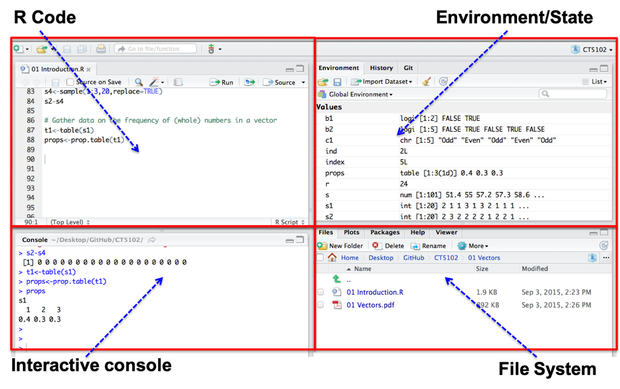

R Studio IDE

## R Data Types

|  | Homogenous | Heterogenous |
| --- | --- | --- |
| 1d | **Atomic Vector** | List |
| 2d | Matrix | Data Frame/Tibble |
| nd | Array |  |

- The basic data structure in R is the Vector
- Vectors come in two flavours:
  - Atomic vectors
  - Lists
- With atomic vectors, all elements have the same type: logical, integer, double (numeric) or character
- **typeof()** **str()** functions useful

## Atomic Vectors - Examples

```r
dbl_var <- c(2.9, 3.1, 4.8)
typeof(dbl_var)
```

```
## [1] "double"
```

```r
int_var <- c(0L, 1L, 2L)
typeof(int_var)
```

```
## [1] "integer"
```

```r
log_var <- c(TRUE, TRUE, FALSE, T, F)
typeof(log_var)
```

```
## [1] "logical"
```

```r
str_var <- c("Dublin", "London", "Edinburgh")
typeof(str_var)
```

```
## [1] "character"
```

## str() function useful

```r
str(dbl_var)
```

```
##  num [1:3] 2.9 3.1 4.8
```

```r
str(int_var)
```

```
##  int [1:3] 0 1 2
```

```r
str(log_var)
```

```
##  logi [1:5] TRUE TRUE FALSE TRUE FALSE
```

```r
str(str_var)
```

```
##  chr [1:3] "Dublin" "London" "Edinburgh"
```

## Creating Sequences : and seq() function

```r
v1 <- 1:10
v1
```

```
##  [1]  1  2  3  4  5  6  7  8  9 10
```

```r
v2 <- 10:20
v2
```

```
##  [1] 10 11 12 13 14 15 16 17 18 19 20
```

```r
v3 <- seq(20, 30, by=1)
v3
```

```
##  [1] 20 21 22 23 24 25 26 27 28 29 30
```

## Creating Vectors of fixed size (in advance)

```r
v1 <- vector(mode="numeric", length=20)
v1
```

```
##  [1] 0 0 0 0 0 0 0 0 0 0 0 0 0 0 0 0 0 0 0 0
```

```r
v2 <- vector(mode="logical", length=5)
v2
```

```
## [1] FALSE FALSE FALSE FALSE FALSE
```

## Coercion of atomic vectors

- All elements of an atomic vector MUST be of the same type
- When different type are combined, they will be coerced into the most flexible types

|  | **logical** | **integer** | **numeric** | **character** |
| --- | --- | --- | --- | --- |
| **logical** | logical | integer | numeric | character |
| **integer** | integer | integer | numeric | character |
| **numeric** | numeric | numeric | numeric | character |
| **character** | character | character | character | character |

## Coercion Examples

```r
v1 <- c(10, 20, TRUE)
v1
```

```
## [1] 10 20  1
```

```r
typeof(v1)
```

```
## [1] "double"
```

```r
v2 <- c(10, 20, "True")
v2
```

```
## [1] "10"   "20"   "True"
```

```r
typeof(v2)
```

```
## [1] "character"
```

## Challenge 1.1

Determine the types for each of the following vectors

```r
v1 <- c(1L, T, FALSE)
v2 <- c(1L, T, FALSE, 2)
v3 <- c(T, FALSE, 2, "FALSE")
v4 <- c(2L, "FALSE")
v5 <- c(0L, 1L, 2.11)
```

## Subsetting Atomic Vectors

- Subsetting data is a key activity in data science
- R’s subsetting operators are powerful and fast
- For atomic vectors, the operator [ is used
- In R, the index for a vector starts at 1

```r
x <- c( 2.1, 4.2, 3.3, 5.4)
x
```

```
## [1] 2.1 4.2 3.3 5.4
```

```r
x[1]
```

```
## [1] 2.1
```

```r
x[c(1,4)]
```

```
## [1] 2.1 5.4
```

## Subsetting Vectors - (1) Positive Integer

Positive integers return elements at the specified position

```r
x <- 1:10
x
```

```
##  [1]  1  2  3  4  5  6  7  8  9 10
```

```r
x[5]
```

```
## [1] 5
```

```r
x[8:10]
```

```
## [1]  8  9 10
```

## Subsetting Vectors - (2) Negative Integer

Negative integers omit elements at specified positions

```r
x <- 1:10
x
```

```
##  [1]  1  2  3  4  5  6  7  8  9 10
```

```r
x[-5]
```

```
## [1]  1  2  3  4  6  7  8  9 10
```

```r
x[-(8:10)]
```

```
## [1] 1 2 3 4 5 6 7
```

```r
x[-(2:10)]
```

```
## [1] 1
```

## Subsetting Vectors - (3) Logical Vectors

- Select elements where the corresponding logical value is TRUE.
- This approach supports recycling

```r
x <- 1:5
x
```

```
## [1] 1 2 3 4 5
```

```r
x[c(F,T,T,T,T)]
```

```
## [1] 2 3 4 5
```

```r
x[c(F,T)]
```

```
## [1] 2 4
```

## Logical Vectors - Can be formed with logical expressions

```r
x <- 1:5
x
```

```
## [1] 1 2 3 4 5
```

```r
lx <- x < 2
lx
```

```
## [1]  TRUE FALSE FALSE FALSE FALSE
```

```r
x[lx]
```

```
## [1] 1
```

```r
x[x>2]
```

```
## [1] 3 4 5
```

## Subsetting Vectors - (4) Using character vectors

Return elements with matching names

```r
x <- 1:5
names(x) <- c("a","b","c","d","e")
x
```

```
## a b c d e
## 1 2 3 4 5
```

```r
x["a"]
```

```
## a
## 1
```

```r
x[c("a","e")]
```

```
## a e
## 1 5
```

## Challenge 1.2

- Create an R vector of squares of 1 to 10
- Find the minimum
- Find the maximum
- Find the average
- Subset all those values greater than the average

## Vectorisation

- A powerful feature of R is that it supports vectorisation
- Functions can operate on every element of a vector, and return the results of each individual operation in a new vector.

```r
x <- c(1,4,9,16,25)
x
```

```
## [1]  1  4  9 16 25
```

```r
y <- sqrt(x)
y
```

```
## [1] 1 2 3 4 5
```

## Vectorisation

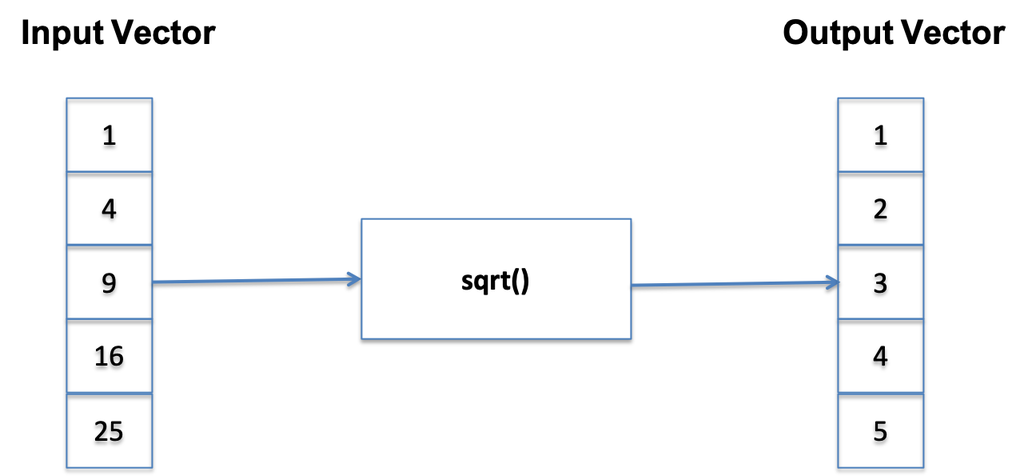

Vectorisation in R

## Vectorised if/else

Vectors can also be processed using the vectorized ifelse(b,u,v) function, which accepts a boolean vector b and allocates the element-wise results to be either u or v.

```r
v1 <- 1:5

ans <- ifelse(v1 %% 2 == 0, "Even", "Odd")
ans
```

```
## [1] "Odd"  "Even" "Odd"  "Even" "Odd"
```

## Sample Function

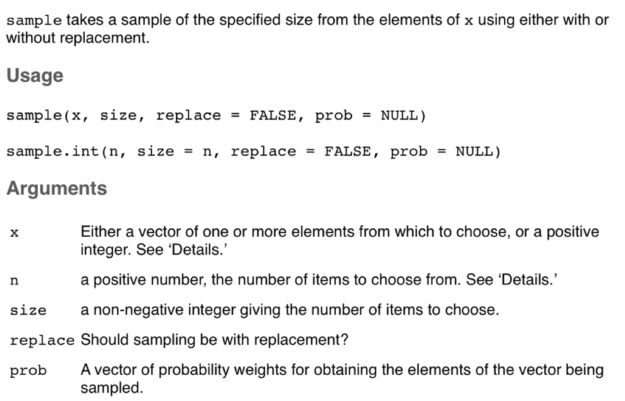

Sample function in Base R

```r
s <- sample(c("Y","N"),10,prob=c(.2,.8),repl=T)
s
```

```
##  [1] "N" "N" "Y" "N" "N" "N" "Y" "N" "N" "Y"
```

## NA Symbol in R (Not available)

- In a project of any size, data is likely to be incomplete due to
  - Missed survey questions
  - Faulty equipment
  - Improperly coded data
- In R, missing data is represented by the symbol NA

```r
x <- 1:5
x[3] <- NA
x
```

```
## [1]  1  2 NA  4  5
```

```r
sum(x)
```

```
## [1] NA
```

```r
sum(x, na.rm=TRUE)
```

```
## [1] 12
```

## Testing for NA? Need **is.na()** function

- The function is.na() indicates which elements are missing
- Returns a logical vector, the same size as the input vector

```r
x
```

```
## [1]  1  2 NA  4  5
```

```r
is.na(x)
```

```
## [1] FALSE FALSE  TRUE FALSE FALSE
```

```r
which(is.na(x)) # get the location of NA
```

```
## [1] 3
```

```r
x[!is.na(x)] # Exclude all NAs from result
```

```
## [1] 1 2 4 5
```

## Test Slide with Plot

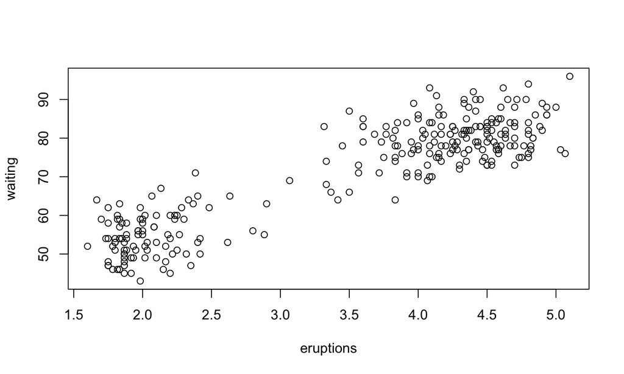